# Mini Tutorial 2: Mapping

“All work presented is my own. I have not communicated with or worked with anyone else on this exam.” -Maddox Ormiston

## Introduction

The goal of this tutorial is to show how mapping can be used to display variables spatially to provide tools for comparison. The data used contains the population for each county in Idaho as of the beginning of 2022. At the completion, we want to compare county’s populations with others in the state.

## Mapping

The code below shows the reading in of the libraries necessary:

```r
library(maps)
library(tidyverse)
library(readr)
library(usdata)
library(here)
```

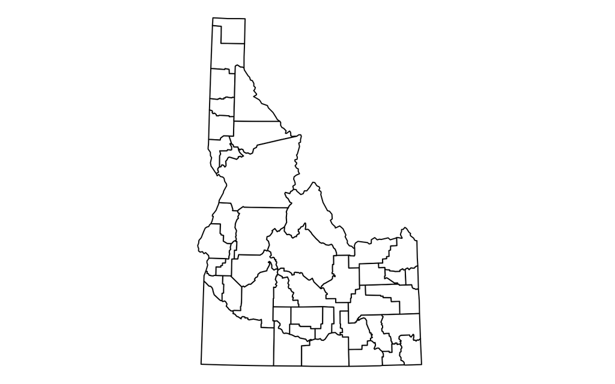

```r
county_df <- ggplot2::map_data("county")
idahocounty_df <- county_df %>% filter(region == "idaho")
ggplot(data = idahocounty_df, aes(x = long, y = lat)) +
  geom_polygon(fill = "white", colour = "black", aes(group = group)) +
  coord_map(projection = "albers", lat0 = 39, lat1 = 45) +
  theme_void()
```

```r
idahocounty_df$subregion <- paste0(idahocounty_df$subregion, " County")

idahocounty_df$subregion <- str_to_title(idahocounty_df$subregion)

pop_df <- read_csv(here("data/csvData.csv"))

countypop_df <- left_join(idahocounty_df, pop_df, by = c("subregion" = "CTYNAME"))
```

Using the longitude and latitude variables that are provided in the maps package and grouping by the county, geom_polygon() is used to create the projection of the state:

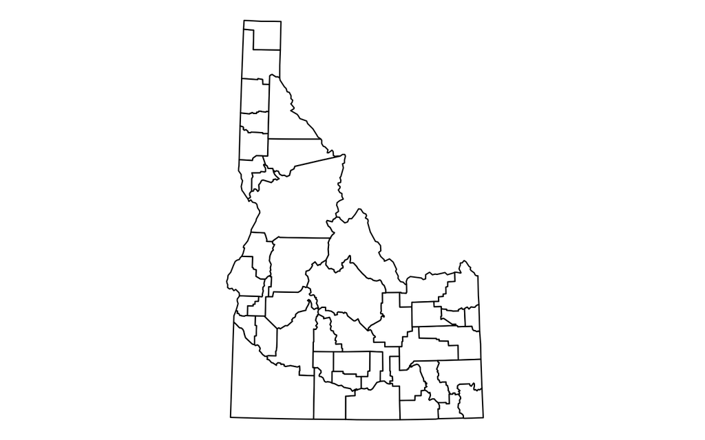

```r
ggplot(data = countypop_df, aes(x = long, y = lat)) +
  geom_polygon(colour = "black", fill = "white", aes(group = group)) +
  coord_map(projection = "albers", lat0 = 39, lat1 = 45) +
  theme_void()
```

To add the component of population comparison, the fill argument in the geom_polygon() mapping creates a map with the values of the population variable dictating the fill color of the county.

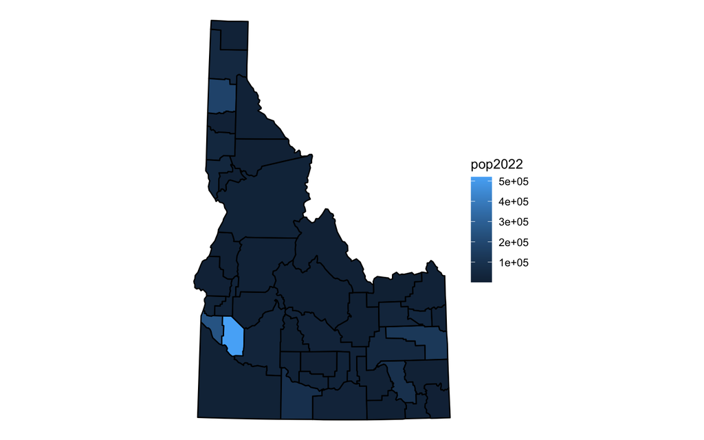

```r
ggplot(data = countypop_df, aes(x = long, y = lat)) +
  geom_polygon(colour = "black", aes(group = group, fill = pop2022)) +
  coord_map(projection = "albers", lat0 = 39, lat1 = 45) +
  theme_void()
```

It is important to note the map projection is important, as the aspect ratio can be extremely skewed without a specified coordinate system. Below is a map with the default projection:

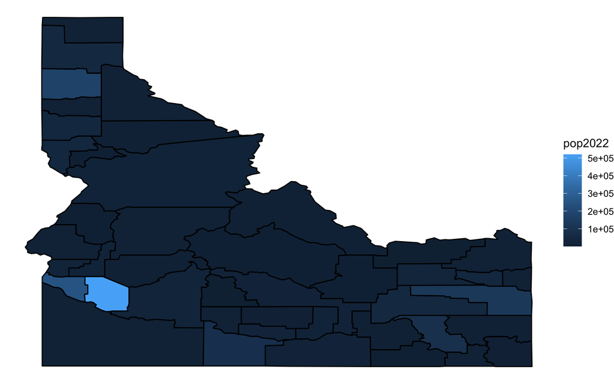

```r
ggplot(data = countypop_df, aes(x = long, y = lat)) +
  geom_polygon(colour = "black", aes(group = group, fill = pop2022)) +
  theme_void()
```